# Integration of snRNA & snATAC using bindSC

Jinzhuang Dou @ KenChen’lab (MDACC)

February 12, 2021

This guide will demonstrate the usage of bindSC to jointly define cell types by leveraging mulitple single-cell modalities. Here we define cell types that incorporate both gene expression and chromatin accessibility data. The dataset is generated from the 10x multiOme of mouse retina cell altals. The dataset will be provided soon.

#### Stage 1: Load the scRNA-seq and scATAC-seq data with seurat object

```r
library(bindSC)
rna <- readRDS(file="./../../data/retina_10x.rna.RDS")
atac <- readRDS(file="./../../data/retina_10x.atac.RDS")



vega_20_scanpy = c(
    '#1F77B4', '#FF7F0E', '#2CA02C', '#D62728', '#9467BD',
    '#8C564B', '#E377C2', '#BCBD22', '#17BECF', '#AEC7E8',
    '#FFBB78', '#98DF8A', '#FF9896', '#C5B0D5', '#C49C94',
    '#F7B6D2', '#DBDB8D', '#9EDAE5', '#AD494A', '#8C6D31')
```

We gate BC cell type only for demonstration

```r
cell_sel <- rownames(rna@meta.data)[grepl("BC",rna@meta.data$celltype)]
rna <- subset(rna, cells = cell_sel)
atac <- subset(atac, cells = cell_sel)
rna <- FindVariableFeatures(rna, nfeatures = 5000)
DefaultAssay(atac) <- "ACTIVITY"
atac <- FindVariableFeatures(atac, nfeatures = 5000)
gene.use <- intersect(VariableFeatures(rna),
                      VariableFeatures(atac))
X <- rna[["RNA"]][gene.use,]
Y <- atac[["ATAC"]][]
Z0 <- atac[["ACTIVITY"]][gene.use]
type <- c(rep("RNA", ncol(X)), rep("ATAC", ncol(X)))

a <- rowSums(as.matrix(Y))
Y <- Y[a>50,]
```

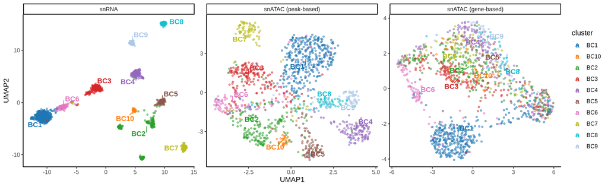

```r
library(Seurat)
library(ggplot2)
library(ggrepel)

DefaultAssay(atac) <- "ATAC"
atac <- RunLSI(atac, n =50,features = rownames(atac)[a>50])
atac <- FindNeighbors(atac, dims = 1:20, reduction = "lsi")
atac <- FindClusters(atac, resolution = 0.5)
atac <- RunUMAP(atac, reduction = "lsi", dims = 1:15)


DefaultAssay(atac) <- "ACTIVITY"

atac <- RunPCA(atac,npcs = 50)
atac <- FindNeighbors(atac, dims = 1:20, reduction = "pca")
atac <- FindClusters(atac, resolution = 0.5)
atac <- RunUMAP(atac, reduction = "pca", dims = 1:15, reduction.name="gene.umap")


b <- X
rownames(b)<-rownames(X)
colnames(b) <-colnames(X)
rna1 <- CreateSeuratObject(counts = b)
rna1 <- ScaleData(rna1)
rna1 <- RunPCA(rna1,npcs = 50, features = rownames(rna1))
rna1 <- FindNeighbors(rna1, dims = 1:20, reduction = "pca")
rna1 <- FindClusters(rna1, resolution = 0.5)
rna1 <- RunUMAP(rna1, reduction = "pca", dims = 1:30, reduction.name="gene.umap")
rna1@meta.data$celltype  <- rna@meta.data$celltype
Idents(rna1) <- rna1@meta.data$celltype


n <- nrow(rna1@meta.data)

plt_dt <- rbind(rna1@reductions$gene.umap@cell.embeddings ,
                atac@reductions$gene.umap@cell.embeddings,
                atac@reductions$umap@cell.embeddings
                )
plt_dt <- as.data.frame(plt_dt)
plt_dt$data <- c(rep("snRNA",n ), rep("snATAC (gene-based)",n ), rep("snATAC (peak-based)", n))
plt_dt$cluster<-c(rna1@meta.data$celltype, rna1@meta.data$celltype,rna1@meta.data$celltype)


colnames(plt_dt)<-c("UMAP1","UMAP2", "data", "cluster")
plt_dt$data<-factor(plt_dt$data,levels=c("snRNA","snATAC (peak-based)","snATAC (gene-based)"))

label_pos<-aggregate(. ~ cluster + data, plt_dt[,c("cluster","data",  "UMAP1","UMAP2")], median)

library(ggplot2)
p <- ggplot(plt_dt, aes(x = UMAP1, y = UMAP2,  color = cluster)) +
geom_point(alpha = 0.5, size =1)   +
theme(plot.title = element_text(size = 40, face = "bold")) + facet_wrap(~data, scales = "free") +
scale_colour_manual(values = vega_20_scanpy) +
geom_text_repel(data = label_pos, repel = TRUE,
                    aes(label = cluster), fontface="bold",
                    alpha = 1,box.padding = 0.5, point.padding = 0.1) +
    NoLegend() + theme(axis.text=element_blank(), axis.title=element_blank(),
                       axis.ticks=element_blank()) +theme_classic()

p
```

Generally, you can run bindSC using full datasets. However, the feature dimension is high for single cell epigenetic profiles (for example, >100k peaks for scATAC-seq data). Here we use low-dimension representations rather than the orignal matrixs for bindSC alignment. You should perform dimension reductions (SVD) on `X` and `Z0` jointly. This will take ~2 mins

```r
out <- dimReduce( dt1 =  X, dt2 = Z0,  K = 30)
x <- out$dt1
z0 <- out$dt2
y  <- atac@reductions$lsi@cell.embeddings
```

#### Stage 3: Parameter optimization [optional]

There are two key parameters that may influence the integraton results: 1) `lambda` modality weighting factor; 2) `alpha` weighting factor of initilized gene score matrix. The `parameter optimization` step will run bindS alignment with `0<lambda<1` and `0<alpha<1`. THis may take a long time if the sampe size is large.We found the defualt settings with lambda = 0.5 and alpha = 0.5 work well on most integration tasks. You can skip the `parameter optimization` step if you want to use the default settings.

To run the `parameter optimization` step, you need to prepare for the cluster annotaion information for each dataset. The following showing the selection of alpha assuming lambda = 0.5. Overall, the integration metrics are relatively robust when alpah locates in [0.1, 0.5]

```r
x.clst <- rna@meta.data$celltype
y.clst <- atac@meta.data$ATAC_snn_res.0.5
run = TRUE
if(run){
  paraSel <- BiCCA_para_opt( X = t(x) ,
               Y = t(y),
               Z0 =t(z0),
               tp="out",
               X.clst = x.clst,
               Y.clst = y.clst,
               alpha.lst = seq(0,1,0.1),
               K.lst = c(15),
               lambda.lst = c(0.5),
               num.iteration = 50,
               tolerance = 0.01,
               save = TRUE,
               block.size = 0
  )
  paraSel <- as.data.frame(paraSel)
  paraSel$index <- paraSel$silhouette1 +  paraSel$silhouette2 + paraSel$alignment
  p1 <- ggplot(paraSel,aes(x=alpha, y= index)) + geom_line() + geom_point() + ylim(0.6,0.9) + theme_bw() + ylab("silhouette score + alignment score")
}
```

```
## 2022-01-16 20:02:33  Started!
```

```
## 2022-01-16 20:02:33  Dimension Check: X[30x1276] Y[50x1276] Z0[30x1276]
```

```
## 2022-01-16 20:02:33  Parameter optimization is done!
```

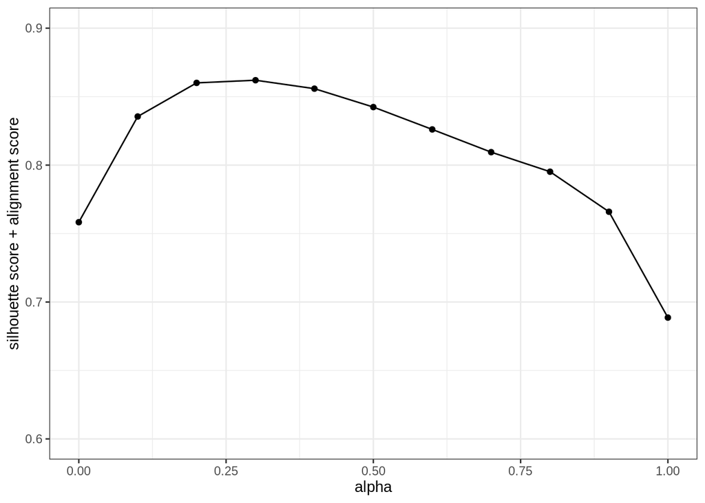

```r
p1
```

#### Stage 4: Run bindSC

We use defualt settings with lambda = 0.5 and alpha = 0.5. The iteration process will be done in ~20s.

```r
res <- BiCCA( X = t(x) ,
             Y = t(y),
             Z0 =t(z0),
             X.clst = x.clst,
             Y.clst = y.clst,
             alpha = 0.5,
             lambda = 0.5,
             K = 15,
             temp.path  = "out",
             num.iteration = 50,
             tolerance = 0.01,
             save = TRUE,
             parameter.optimize = FALSE,
             block.size = 0)
```

```
## 2022-01-16 20:00:11  Started!
```

```
## 2022-01-16 20:00:11  Dimension Check: X[30x1276] Y[50x1276] Z0[30x1276]
```

```
## 2022-01-16 20:00:11  Decomposing started!
```

[output not shown]

```
## 2022-01-16 20:00:21  Done! The decomposition is converged.
```

Check the iteration process using `plotIteration` function (optional). The first row shows the objective function costs for 3 terms separately. The fourth figure shows the total objective function over iteration time. The fifth figure figure shows the relative change of gene score matrix Z over iteration time.

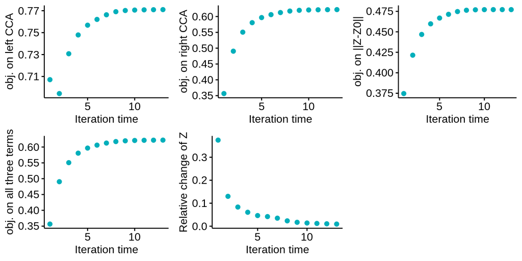

```r
p2 <- plotIteration(res)
p2
```

#### Stage 4: Project cells from two modalites in co-embedding spaces.

res$u` and `res$r` denote the coordinates of two modalites in co-embeddings.

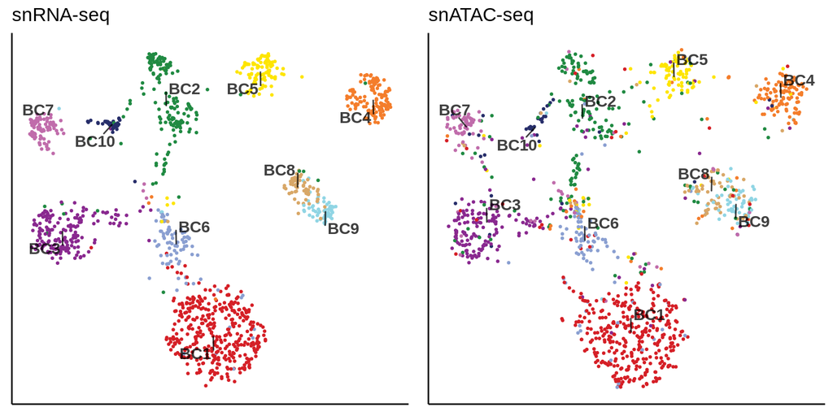

```r
dim(res$u)
dim(res$r)
umap_plt <- umap(rbind(res$u, res$r))
umap_plt  <- data.frame("UMAP1"=umap_plt$layout[,1],
                        "UMAP2"=umap_plt$layout[,2],
                        "celltype" = c(x.clst, x.clst),
                        "data" = c(rep("scRNA-seq",length(x.clst)),
                                   rep("scATAC-seq",length(y.clst))))

xlim <- c(min(umap_plt$UMAP1), max(umap_plt$UMAP1))
ylim <- c(min(umap_plt$UMAP2), max(umap_plt$UMAP2))

p11 <- UMAP_plot(meta = umap_plt[umap_plt$data=="scRNA-seq",],mylabel=paletteDiscrete(umap_plt$celltype),
                color = "celltype", xlim = xlim, ylim = ylim,alpha = 1) + ggtitle("snRNA-seq")
p12 <- UMAP_plot(meta = umap_plt[umap_plt$data=="scATAC-seq",], mylabel=paletteDiscrete(umap_plt$celltype),
              color = "celltype", xlim = xlim, ylim = ylim,alpha = 1)  + ggtitle("snATAC-seq")

p3 <- ggarrange(p11,p12, ncol=2)
print(p3)
```

[output not shown]

#### Stage 4: Impute gene expression profiles for cells from scATAC.

We can also show how bindSC improves the gene score matrix after iteration process using co-assayed cells as validation.

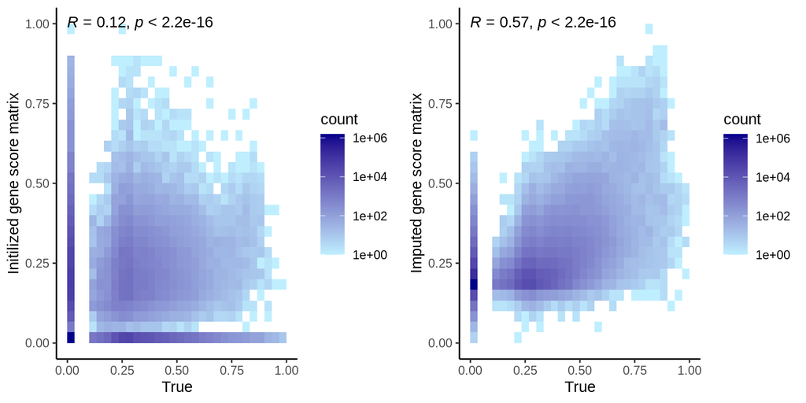

```r
Z_impu <- impuZ(X=rna[["RNA"]][gene.use,], bicca = res)
p5 <- plot_geneScoreChange(X=rna[["RNA"]][gene.use,], Z0 = atac[["ACTIVITY"]][gene.use,], Z_impu = Z_impu)


p5
```